# Taboo: Behavioral analysis

# Load data

```r
# read data
## setwd("/Users/seantrott/Dropbox/UCSD/Research/Ambiguity/Taboo/Experiment1/analysis/reports")
df = read.csv("../../data/processed/behavioral_results_public.csv")
```

## Remove sessions 10 and 15

```r
df = df %>%
  filter((session_id %in% c(10, 15)) == FALSE)

nrow(df)
```

```
## [1] 4377
```

```r
length(unique(df$session_id))
```

```
## [1] 17
```

```r
df = df %>%
   filter(Native_Speaker == "Yes")

nrow(df)
```

```
## [1] 4204
```

## Descriptive statistics

```r
nrow(df)
```

```
## [1] 4204
```

```r
table(df$session_id)
```

```
##
##   1   4   5   6   7   8   9  11  12  13  14  16  17  18  19  20  21
## 256 293 317 313 282 286 306 260 207 250 220 245 212 165 163 262 167
```

```r
table(df$pair_type, df$trial_result)
```

```
##
##            Lost Out of time  Won
##   Friend    681         260 1176
##   Stranger  660         268 1159
```

```r
table(df$Order)
```

```
##
## Friend_Stranger Stranger_Friend
##            2213            1991
```

```r
length(unique(df$session_id))
```

```
## [1] 17
```

```r
length(unique(df$ppt_id))
```

```
## [1] 65
```

```r
## How many trials per session?
df_session = df %>%
  group_by(session_id, Order) %>%
  summarise(count = n())
mean(df_session$count)
```

```
## [1] 247.2941
```

```r
median(df_session$count)
```

```
## [1] 256
```

```r
sd(df_session$count)
```

```
## [1] 51.12456
```

```r
table(df_session$Order)
```

```
##
## Friend_Stranger Stranger_Friend
##               9               8
```

### Check data

```r
df_demo = df %>%
  group_by(ppt_id, Played_before, Gender, Native_Speaker) %>%
  summarise(vocab = mean(MINT_Score_Uncued_Correct),
            taboo = mean(Taboo_expertise))
table(df_demo$Native_Speaker)
```

```
##
##  No Yes
##   0  65
```

```r
table(df_demo$taboo)
```

```
##
##  1  2  3  4  5
## 14 11 27 12  1
```

```r
df_demo %>%
  group_by(Native_Speaker) %>%
  summarise(mean_mint = mean(vocab),
            count = n())
```

```
## # A tibble: 1 × 3
##   Native_Speaker mean_mint count
##   <fct>              <dbl> <int>
## 1 Yes                 20.5    65
```

### Participant-level characteristics

People scored very high on the MINT in general; the lowest score was 19.

```r
df_demo = df %>%
  group_by(ppt_id, Played_before, Gender) %>%
  summarise(vocab = mean(MINT_Score_Uncued_Correct),
            taboo = mean(Taboo_expertise))
table(df_demo$Gender)
```

```
##
##     Female       Male Non-binary
##         49         15          1
```

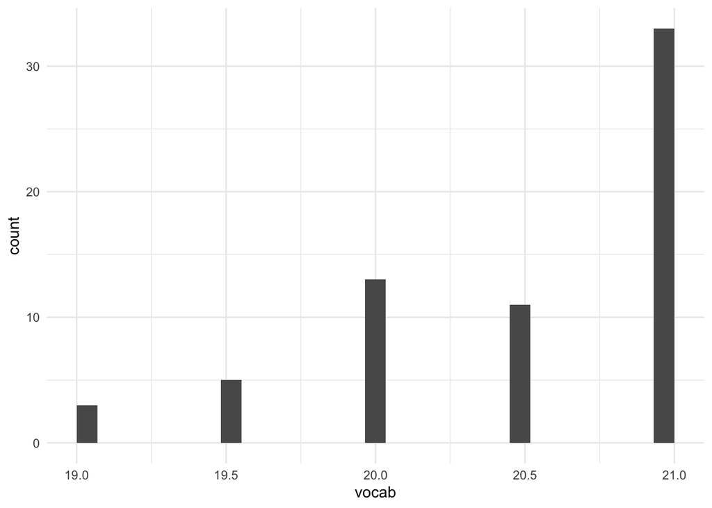

```r
df_demo %>%
  ggplot(aes(x = vocab)) +
  geom_histogram() +
  theme_minimal()
```

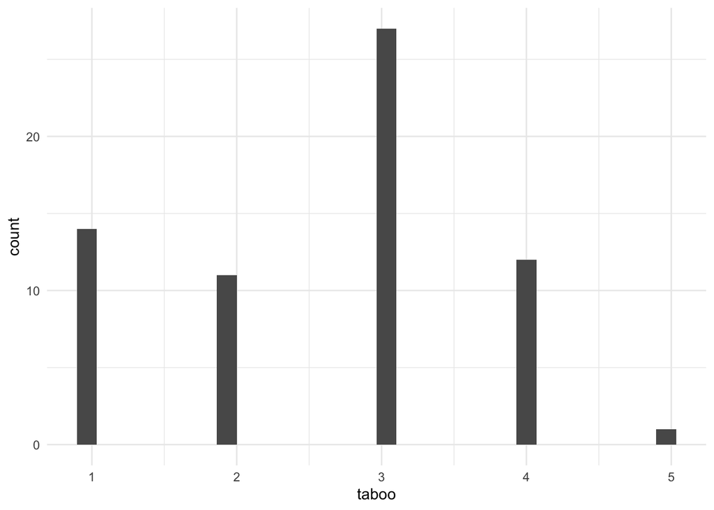

```r
df_demo %>%
  ggplot(aes(x = taboo)) +
  geom_histogram() +
  theme_minimal()
```

```r
table(df_demo$Played_before)
```

```
##
##  No Yes
##  31  34
```

```r
mean(df_demo$taboo)
```

```
## [1] 2.615385
```

```r
sd(df_demo$taboo)
```

```
## [1] 1.07081
```

### Partner closeness scores

Strangers were automatically assigned a closeness score of 0.

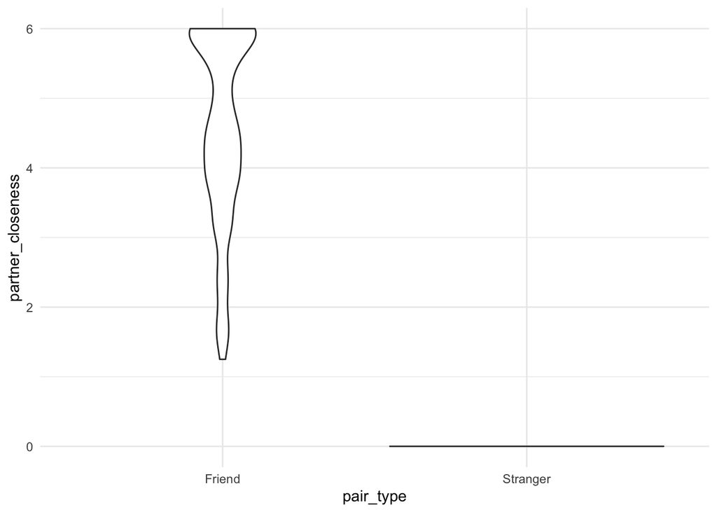

```r
df %>%
  ggplot(aes(x = pair_type,
             y = partner_closeness)) +
  geom_violin() +
  theme_minimal()
```

```r
df %>%
  group_by(pair_type) %>%
  summarise(closeness = mean(partner_closeness),
            sd_close = sd(partner_closeness))
```

```
## # A tibble: 2 × 3
##   pair_type closeness sd_close
##   <fct>         <dbl>    <dbl>
## 1 Friend         4.53     1.36
## 2 Stranger       0        0
```

# Modeling trial outcomes

There are three possible outcomes:

1. **Winning**: The listener successfully guesses the card.
2. **Losing**: The speaker says a taboo word or gestures. (Or, for sessions 1-12, the speaker "skips" the card.)
3. **Out of time**: The pair runs out of time on the card.

There are a few ways we might want to *model* these outcomes. We could group (2) and (3) together as a larger category of "Losing". Alternatively, we could analyze `Win` vs. `Lose` separately from `Win` vs. `Out of time`. The issue is complicated by the fact that speakers were allowed to skip cards for session 1-12; if $p(skip)$ differs as a function of `pair_type`, that might in turn affect the distribution of outcomes.

## Descriptive statistics

```r
table(df$trial_result) / nrow(df)
```

```
##
##        Lost Out of time         Won
##   0.3189819   0.1255947   0.5554234
```

```r
table(df$pair_type, df$trial_result) / nrow(df)
```

```
##
##                  Lost Out of time        Won
##   Friend   0.16198858  0.06184586 0.27973359
##   Stranger 0.15699334  0.06374881 0.27568982
```

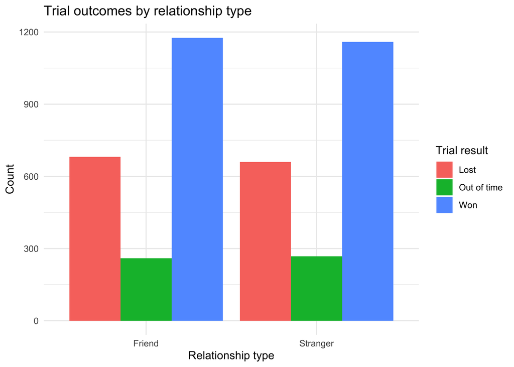

```r
df %>%
  ggplot(aes(x = pair_type,
             fill = trial_result)) +
  geom_bar(stat = "count", position = "dodge") +
  guides(fill=guide_legend(title="Trial result")) +
  labs(x = "Relationship type",
       y = "Count",
       title = "Trial outcomes by relationship type") +
  theme_minimal()
```

## Winning vs. out of time

### All sessions

First, we limit our analysis to trials that were either explicitly won or ran out of time.

```r
df_win_lose = df %>%
  filter(trial_result %in% c("Won", "Out of time"))

nrow(df_win_lose)
```

```
## [1] 2863
```

#### Note on random effects structure

Following Barr et al (2013), I begin with the **maximal** random effects structure including all random factors that could explain variance: `ppt_id`, `partner_id`, `Order`, `session_id`, and `deck` (`color`).

I then added a random slope for each random factor for the fixed effect of `pair_type`, which is the main variable we are interested in examining. Then, using nested model comparisons, I selected the random effects structure that was best justified by the data.

In terms of random slopes, the only factor for which a random slope of `pair_type` explained significant variance was `Order` (i.e., whether participants played with their friend or with a stranger first; strangers were worse when that session began with strangers than when that session began with friends). All random intercepts tested explained additional variance.

```r
model_final_base = glmer(data = df_win_lose,
                              trial_result ~
                                (1 | ppt_id) +
                                (1 | partner_id) +
                                (1 + pair_type | Order) +
                                (1 | session_id) +
                                (1 | color),
                              control=glmerControl(optimizer="bobyqa"),
                              family = binomial())
```

```
## boundary (singular) fit: see ?isSingular
```

#### Model comparisons

Now we add the covariates that might be important to account for.

It looks like the MINT score explains a very small amount of variance, and `trial_with_partner` explains significant amounts of variance. The probability of winning (relative to running out of time) increases with each trial one has with a partner.

```r
model_covariates = glmer(data = df_win_lose,
                          trial_result ~
                          Taboo_expertise +
                           MINT_Score_Uncued_Correct +
                           trial_with_partner +
                          (1 | ppt_id) +
                          (1 | partner_id) +
                          (1 + pair_type | Order) +
                          (1 | session_id) +
                          (1 | color),
                        control=glmerControl(optimizer="bobyqa"),
                        family = binomial())
model_no_mint = glmer(data = df_win_lose,
                          trial_result ~
                          Taboo_expertise +
                           # MINT_Score_Uncued_Correct +
                           trial_with_partner +
                          (1 | ppt_id) +
                          (1 | partner_id) +
                          (1 + pair_type | Order) +
                          (1 | session_id) +
                          (1 | color),
                        control=glmerControl(optimizer="bobyqa"),
                        family = binomial())
```

```
## boundary (singular) fit: see ?isSingular
```

```r
model_no_taboo = glmer(data = df_win_lose,
                          trial_result ~
                          # Taboo_expertise +
                           MINT_Score_Uncued_Correct +
                           trial_with_partner +
                          (1 | ppt_id) +
                          (1 | partner_id) +
                          (1 + pair_type | Order) +
                          (1 | session_id) +
                          (1 | color),
                        control=glmerControl(optimizer="bobyqa"),
                        family = binomial())
```

```
## boundary (singular) fit: see ?isSingular
```

```r
model_no_turn_order = glmer(data = df_win_lose,
                          trial_result ~
                          Taboo_expertise +
                           MINT_Score_Uncued_Correct +
                           # trial_with_partner +
                          (1 | ppt_id) +
                          (1 | partner_id) +
                          (1 + pair_type | Order) +
                          (1 | session_id) +
                          (1 | color),
                        control=glmerControl(optimizer="bobyqa"),
                        family = binomial())
```

```
## boundary (singular) fit: see ?isSingular
```

```r
anova(model_covariates, model_no_mint)
```

```
## Data: df_win_lose
## Models:
## model_no_mint: trial_result ~ Taboo_expertise + trial_with_partner + (1 | ppt_id) +
## model_no_mint:     (1 | partner_id) + (1 + pair_type | Order) + (1 | session_id) +
## model_no_mint:     (1 | color)
## model_covariates: trial_result ~ Taboo_expertise + MINT_Score_Uncued_Correct +
## model_covariates:     trial_with_partner + (1 | ppt_id) + (1 | partner_id) + (1 +
## model_covariates:     pair_type | Order) + (1 | session_id) + (1 | color)
##                  npar    AIC    BIC  logLik deviance  Chisq Df Pr(>Chisq)
## model_no_mint      10 2584.4 2644.0 -1282.2   2564.4
## model_covariates   11 2586.1 2651.7 -1282.1   2564.1 0.2344  1     0.6283
```

```r
anova(model_covariates, model_no_taboo)
```

```
## Data: df_win_lose
## Models:
## model_no_taboo: trial_result ~ MINT_Score_Uncued_Correct + trial_with_partner +
## model_no_taboo:     (1 | ppt_id) + (1 | partner_id) + (1 + pair_type | Order) +
## model_no_taboo:     (1 | session_id) + (1 | color)
## model_covariates: trial_result ~ Taboo_expertise + MINT_Score_Uncued_Correct +
## model_covariates:     trial_with_partner + (1 | ppt_id) + (1 | partner_id) + (1 +
## model_covariates:     pair_type | Order) + (1 | session_id) + (1 | color)
##                  npar    AIC    BIC  logLik deviance  Chisq Df Pr(>Chisq)
## model_no_taboo     10 2584.4 2644.0 -1282.2   2564.4
## model_covariates   11 2586.1 2651.7 -1282.1   2564.1 0.2733  1     0.6011
```

```r
anova(model_covariates, model_no_turn_order)
```

```
## Data: df_win_lose
## Models:
## model_no_turn_order: trial_result ~ Taboo_expertise + MINT_Score_Uncued_Correct +
## model_no_turn_order:     (1 | ppt_id) + (1 | partner_id) + (1 + pair_type | Order) +
## model_no_turn_order:     (1 | session_id) + (1 | color)
## model_covariates: trial_result ~ Taboo_expertise + MINT_Score_Uncued_Correct +
## model_covariates:     trial_with_partner + (1 | ppt_id) + (1 | partner_id) + (1 +
## model_covariates:     pair_type | Order) + (1 | session_id) + (1 | color)
##                     npar    AIC    BIC  logLik deviance Chisq Df Pr(>Chisq)
## model_no_turn_order   10 2592.7 2652.2 -1286.3   2572.7
## model_covariates      11 2586.1 2651.7 -1282.1   2564.1 8.517  1   0.003518 **
## ---
## Signif. codes:  0 '***' 0.001 '**' 0.01 '*' 0.05 '.' 0.1 ' ' 1
```

```r
summary(model_covariates)
```

```
## Generalized linear mixed model fit by maximum likelihood (Laplace
##   Approximation) [glmerMod]
##  Family: binomial  ( logit )
## Formula: trial_result ~ Taboo_expertise + MINT_Score_Uncued_Correct +
##     trial_with_partner + (1 | ppt_id) + (1 | partner_id) + (1 +
##     pair_type | Order) + (1 | session_id) + (1 | color)
##    Data: df_win_lose
## Control: glmerControl(optimizer = "bobyqa")
##
##      AIC      BIC   logLik deviance df.resid
##   2586.1   2651.7  -1282.1   2564.1     2852
##
## Scaled residuals:
##     Min      1Q  Median      3Q     Max
## -5.0414  0.2281  0.3747  0.5315  0.9441
##
## Random effects:
##  Groups     Name              Variance Std.Dev. Corr
##  partner_id (Intercept)       0.032559 0.18044
##  ppt_id     (Intercept)       0.015778 0.12561
##  session_id (Intercept)       0.503847 0.70982
##  color      (Intercept)       0.035024 0.18715
##  Order      (Intercept)       0.002013 0.04486
##             pair_typeStranger 0.154801 0.39345  -1.00
## Number of obs: 2863, groups:
## partner_id, 68; ppt_id, 65; session_id, 17; color, 4; Order, 2
##
## Fixed effects:
##                            Estimate Std. Error z value Pr(>|z|)
## (Intercept)                2.575131   2.754714   0.935  0.34989
## Taboo_expertise           -0.028273   0.060803  -0.465  0.64193
## MINT_Score_Uncued_Correct -0.055876   0.133135  -0.420  0.67471
## trial_with_partner         0.016428   0.005621   2.923  0.00347 **
## ---
## Signif. codes:  0 '***' 0.001 '**' 0.01 '*' 0.05 '.' 0.1 ' ' 1
##
## Correlation of Fixed Effects:
##             (Intr) Tb_xpr MINT_S
## Taboo_xprts -0.116
## MINT_Sc_U_C -0.995  0.059
## trl_wth_prt -0.071 -0.018  0.042
## convergence code: 1
## Model failed to converge with max|grad| = 0.0122127 (tol = 0.002, component 1)
```

#### Primary analyses

```r
model_interaction = glmer(data = df_win_lose,
                          trial_result ~
                            pair_type * trial_with_partner +
                           MINT_Score_Uncued_Correct +
                          (1 | ppt_id) +
                          (1 | partner_id) +
                          (1 + pair_type | Order) +
                          (1 | session_id) +
                          (1 | color),
                        # control=glmerControl(optimizer="bobyqa"),
                        family = binomial())
```

```
## boundary (singular) fit: see ?isSingular
```

```r
model_with_pair_type = glmer(data = df_win_lose,
                          trial_result ~
                            pair_type +
                           MINT_Score_Uncued_Correct +
                           trial_with_partner +
                          (1 | ppt_id) +
                          (1 | partner_id) +
                          (1 + pair_type | Order) +
                          (1 | session_id) +
                          (1 | color),
                        control=glmerControl(optimizer="bobyqa"),
                        family = binomial())
```

```
## boundary (singular) fit: see ?isSingular
```

```r
model_final_base = glmer(data = df_win_lose,
                          trial_result ~
                           MINT_Score_Uncued_Correct +
                           trial_with_partner +
                          (1 | ppt_id) +
                          (1 | partner_id) +
                          (1 + pair_type | Order) +
                          (1 | session_id) +
                          (1 | color),
                        control=glmerControl(optimizer="bobyqa"),
                        family = binomial())
```

```
## boundary (singular) fit: see ?isSingular
```

```r
model_no_turn = glmer(data = df_win_lose,
                          trial_result ~
                           MINT_Score_Uncued_Correct +
                           trial_with_partner +
                          (1 | ppt_id) +
                          (1 | partner_id) +
                          (1 + pair_type | Order) +
                          (1 | session_id) +
                          (1 | color),
                        control=glmerControl(optimizer="bobyqa"),
                        family = binomial())
```

```
## boundary (singular) fit: see ?isSingular
```

```r
summary(model_interaction)
```

```
## Generalized linear mixed model fit by maximum likelihood (Laplace
##   Approximation) [glmerMod]
##  Family: binomial  ( logit )
## Formula:
## trial_result ~ pair_type * trial_with_partner + MINT_Score_Uncued_Correct +
##     (1 | ppt_id) + (1 | partner_id) + (1 + pair_type | Order) +
##     (1 | session_id) + (1 | color)
##    Data: df_win_lose
##
##      AIC      BIC   logLik deviance df.resid
##   2586.9   2658.4  -1281.4   2562.9     2851
##
## Scaled residuals:
##     Min      1Q  Median      3Q     Max
## -5.2881  0.2246  0.3739  0.5278  0.9424
##
## Random effects:
##  Groups     Name              Variance Std.Dev. Corr
##  partner_id (Intercept)       0.03431  0.1852
##  ppt_id     (Intercept)       0.01537  0.1240
##  session_id (Intercept)       0.50961  0.7139
##  color      (Intercept)       0.03408  0.1846
##  Order      (Intercept)       0.00000  0.0000
##             pair_typeStranger 0.14850  0.3854    NaN
## Number of obs: 2863, groups:
## partner_id, 68; ppt_id, 65; session_id, 17; color, 4; Order, 2
##
## Fixed effects:
##                                       Estimate Std. Error z value Pr(>|z|)
## (Intercept)                           2.595048   2.727916   0.951    0.341
## pair_typeStranger                    -0.217788   0.332102  -0.656    0.512
## trial_with_partner                    0.009497   0.007832   1.213    0.225
## MINT_Score_Uncued_Correct            -0.055485   0.132338  -0.419    0.675
## pair_typeStranger:trial_with_partner  0.013745   0.011020   1.247    0.212
##
## Correlation of Fixed Effects:
##             (Intr) pr_tyS trl_w_ MINT_S
## pr_typStrng -0.031
## trl_wth_prt -0.087  0.343
## MINT_Sc_U_C -0.996  0.011  0.044
## pr_typSt:__  0.046 -0.484 -0.697 -0.016
## convergence code: 0
## boundary (singular) fit: see ?isSingular
```

```r
anova(model_interaction, model_with_pair_type)
```

```
## Data: df_win_lose
## Models:
## model_with_pair_type: trial_result ~ pair_type + MINT_Score_Uncued_Correct + trial_with_partner +
## model_with_pair_type:     (1 | ppt_id) + (1 | partner_id) + (1 + pair_type | Order) +
## model_with_pair_type:     (1 | session_id) + (1 | color)
## model_interaction: trial_result ~ pair_type * trial_with_partner + MINT_Score_Uncued_Correct +
## model_interaction:     (1 | ppt_id) + (1 | partner_id) + (1 + pair_type | Order) +
## model_interaction:     (1 | session_id) + (1 | color)
##                      npar    AIC    BIC  logLik deviance  Chisq Df Pr(>Chisq)
## model_with_pair_type   11 2586.4 2652.0 -1282.2   2564.4
## model_interaction      12 2586.9 2658.4 -1281.4   2562.9 1.5313  1     0.2159
```

```r
anova(model_with_pair_type, model_final_base)
```

```
## Data: df_win_lose
## Models:
## model_final_base: trial_result ~ MINT_Score_Uncued_Correct + trial_with_partner +
## model_final_base:     (1 | ppt_id) + (1 | partner_id) + (1 + pair_type | Order) +
## model_final_base:     (1 | session_id) + (1 | color)
## model_with_pair_type: trial_result ~ pair_type + MINT_Score_Uncued_Correct + trial_with_partner +
## model_with_pair_type:     (1 | ppt_id) + (1 | partner_id) + (1 + pair_type | Order) +
## model_with_pair_type:     (1 | session_id) + (1 | color)
##                      npar    AIC  BIC  logLik deviance  Chisq Df Pr(>Chisq)
## model_final_base       10 2584.4 2644 -1282.2   2564.4
## model_with_pair_type   11 2586.4 2652 -1282.2   2564.4 0.0038  1     0.9508
```

```r
anova(model_with_pair_type, model_no_turn)
```

```
## Data: df_win_lose
## Models:
## model_no_turn: trial_result ~ MINT_Score_Uncued_Correct + trial_with_partner +
## model_no_turn:     (1 | ppt_id) + (1 | partner_id) + (1 + pair_type | Order) +
## model_no_turn:     (1 | session_id) + (1 | color)
## model_with_pair_type: trial_result ~ pair_type + MINT_Score_Uncued_Correct + trial_with_partner +
## model_with_pair_type:     (1 | ppt_id) + (1 | partner_id) + (1 + pair_type | Order) +
## model_with_pair_type:     (1 | session_id) + (1 | color)
##                      npar    AIC  BIC  logLik deviance  Chisq Df Pr(>Chisq)
## model_no_turn          10 2584.4 2644 -1282.2   2564.4
## model_with_pair_type   11 2586.4 2652 -1282.2   2564.4 0.0038  1     0.9508
```

We can visualize this effect:

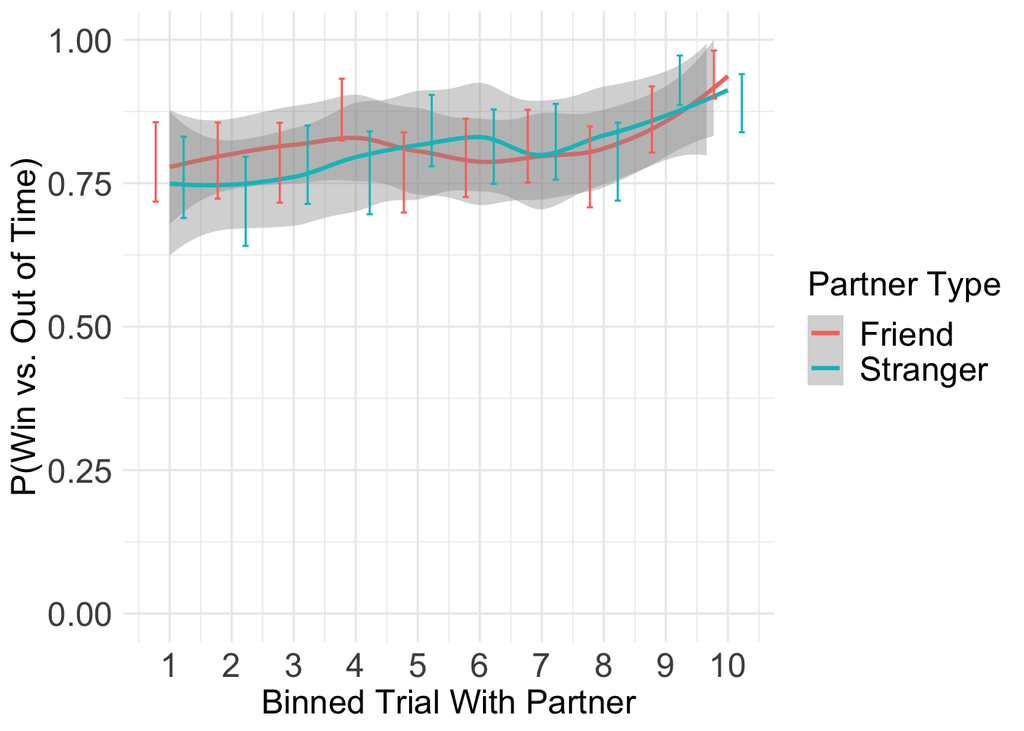

```r
df_win_lose = df_win_lose %>%
  mutate(
    outcome_numeric = case_when(
      trial_result == "Won" ~ 1,
      trial_result == "Out of time" ~ 0
    )
  )


df_win_lose %>%
  mutate(binned_trial = ntile(trial_with_partner, n = 10)) %>%
  group_by(binned_trial, pair_type) %>%
  summarise(success = mean(outcome_numeric),
            se = sd(outcome_numeric)/sqrt(n())) %>%
  ggplot(aes(x = binned_trial,
             y = success,
             color = pair_type)) +
  geom_smooth() +
  geom_errorbar(aes(ymin = success - 2*se,
                  ymax = success + 2*se),
              width=.2,
              position=position_dodge(.9)) +
  labs(x = "Binned Trial With Partner",
       y = "P(Win vs. Out of Time)",
       color = "Partner Type") +
  scale_y_continuous(limits = c(0, 1)) +
  scale_x_continuous(breaks = c(1:10)) +
  theme_minimal() +
  theme(axis.title = element_text(size=rel(1.5)),
        axis.text = element_text(size = rel(1.5)),
        legend.text = element_text(size = rel(1.5)),
        strip.text.x = element_text(size = rel(1.5)),
        plot.title = element_text(size = rel(1.5)),
        legend.title = element_text(size = rel(1.5)))
```

```r
ggsave("../../Figures/behavioral/win_vs_oot.png", dpi = 300)
```

## Winning vs. losing

First, we limit our analysis to trials that were either explicitly won or lost (produced a taboo word or gesture).

```r
df_win_lose2 = df %>%
  filter(trial_result %in% c("Won", "Lost"))

nrow(df_win_lose2)
```

```
## [1] 3676
```

```r
df_win_lose2$trial_result = factor(df_win_lose2$trial_result, levels = c("Lost", "Won"))

table(df_win_lose2$trial_result)
```

```
##
## Lost  Won
## 1341 2335
```

#### Note on random effects structure

Following Barr et al (2013), I begin with the **maximal** random effects structure including all random factors that could explain variance: `ppt_id`, `partner_id`, `Order`, `session_id`, and `deck` (`color`).

I then added a random slope for each random factor for the fixed effect of `pair_type`, which is the main variable we are interested in examining. Then, using nested model comparisons, I selected the random effects structure that was best justified by the data.

No random factors benefitted from a random slope for `pair_type`. Only random intercept for `session_id` explained significant variance, but for now, we live the other random intercepts in provided they don't intereferew ith model fit.

```r
model_final_base = glmer(data = df_win_lose2,
                              trial_result ~
                                (1 | ppt_id) +
                                (1 | partner_id) +
                                (1 | Order) +
                                (1 | session_id) +
                                (1 | color),
                              control=glmerControl(optimizer="bobyqa"),
                              family = binomial())
```

```
## boundary (singular) fit: see ?isSingular
```

#### Model comparisons

Now we add the covariates that might be important to account for.

Only `trial_with_partner` explains significant amounts of variance. Surprisingly, though, the probability of winning (relative to losing by using a taboo word or gesture) **decreases** with each trial one has with a partner.

```r
model_covariates = glmer(data = df_win_lose2,
                          trial_result ~
                          Taboo_expertise +
                           MINT_Score_Uncued_Correct +
                           trial_with_partner +
                          (1 | ppt_id) +
                          (1 | partner_id) +
                          (1 | Order) +
                          (1 | session_id) +
                          (1 | color),
                        control=glmerControl(optimizer="bobyqa"),
                        family = binomial())
```

```
## boundary (singular) fit: see ?isSingular
```

```r
model_no_mint = glmer(data = df_win_lose2,
                          trial_result ~
                          Taboo_expertise +
                           # MINT_Score_Uncued_Correct +
                           trial_with_partner +
                          (1 | ppt_id) +
                          (1 | partner_id) +
                          (1 + pair_type | Order) +
                          (1 | session_id) +
                          (1 | color),
                        control=glmerControl(optimizer="bobyqa"),
                        family = binomial())
```

```
## boundary (singular) fit: see ?isSingular
```

```r
model_no_taboo = glmer(data = df_win_lose2,
                          trial_result ~
                          # Taboo_expertise +
                           MINT_Score_Uncued_Correct +
                           trial_with_partner +
                          (1 | ppt_id) +
                          (1 | partner_id) +
                          (1 | Order) +
                          (1 | session_id) +
                          (1 | color),
                        control=glmerControl(optimizer="bobyqa"),
                        family = binomial())
```

```
## boundary (singular) fit: see ?isSingular
```

```r
model_no_turn_order = glmer(data = df_win_lose2,
                          trial_result ~
                          Taboo_expertise +
                           MINT_Score_Uncued_Correct +
                           # trial_with_partner +
                          (1 | ppt_id) +
                          (1 | partner_id) +
                          (1 | Order) +
                          (1 | session_id) +
                          (1 | color),
                        control=glmerControl(optimizer="bobyqa"),
                        family = binomial())
```

```
## boundary (singular) fit: see ?isSingular
```

```r
anova(model_covariates, model_no_mint)
```

```
## Data: df_win_lose2
## Models:
## model_covariates: trial_result ~ Taboo_expertise + MINT_Score_Uncued_Correct +
## model_covariates:     trial_with_partner + (1 | ppt_id) + (1 | partner_id) + (1 |
## model_covariates:     Order) + (1 | session_id) + (1 | color)
## model_no_mint: trial_result ~ Taboo_expertise + trial_with_partner + (1 | ppt_id) +
## model_no_mint:     (1 | partner_id) + (1 + pair_type | Order) + (1 | session_id) +
## model_no_mint:     (1 | color)
##                  npar    AIC    BIC  logLik deviance Chisq Df Pr(>Chisq)
## model_covariates    9 4718.3 4774.2 -2350.2   4700.3
## model_no_mint      10 4720.5 4782.6 -2350.2   4700.5     0  1          1
```

```r
anova(model_covariates, model_no_taboo)
```

```
## Data: df_win_lose2
## Models:
## model_no_taboo: trial_result ~ MINT_Score_Uncued_Correct + trial_with_partner +
## model_no_taboo:     (1 | ppt_id) + (1 | partner_id) + (1 | Order) + (1 | session_id) +
## model_no_taboo:     (1 | color)
## model_covariates: trial_result ~ Taboo_expertise + MINT_Score_Uncued_Correct +
## model_covariates:     trial_with_partner + (1 | ppt_id) + (1 | partner_id) + (1 |
## model_covariates:     Order) + (1 | session_id) + (1 | color)
##                  npar    AIC    BIC  logLik deviance  Chisq Df Pr(>Chisq)
## model_no_taboo      8 4716.3 4766.0 -2350.2   4700.3
## model_covariates    9 4718.3 4774.2 -2350.2   4700.3 0.0061  1      0.938
```

```r
anova(model_covariates, model_no_turn_order)
```

```
## Data: df_win_lose2
## Models:
## model_no_turn_order: trial_result ~ Taboo_expertise + MINT_Score_Uncued_Correct +
## model_no_turn_order:     (1 | ppt_id) + (1 | partner_id) + (1 | Order) + (1 | session_id) +
## model_no_turn_order:     (1 | color)
## model_covariates: trial_result ~ Taboo_expertise + MINT_Score_Uncued_Correct +
## model_covariates:     trial_with_partner + (1 | ppt_id) + (1 | partner_id) + (1 |
## model_covariates:     Order) + (1 | session_id) + (1 | color)
##                     npar    AIC    BIC  logLik deviance  Chisq Df Pr(>Chisq)
## model_no_turn_order    8 4741.8 4791.5 -2362.9   4725.8
## model_covariates       9 4718.3 4774.2 -2350.2   4700.3 25.496  1  4.434e-07
##
## model_no_turn_order
## model_covariates    ***
## ---
## Signif. codes:  0 '***' 0.001 '**' 0.01 '*' 0.05 '.' 0.1 ' ' 1
```

```r
summary(model_covariates)
```

```
## Generalized linear mixed model fit by maximum likelihood (Laplace
##   Approximation) [glmerMod]
##  Family: binomial  ( logit )
## Formula: trial_result ~ Taboo_expertise + MINT_Score_Uncued_Correct +
##     trial_with_partner + (1 | ppt_id) + (1 | partner_id) + (1 |
##     Order) + (1 | session_id) + (1 | color)
##    Data: df_win_lose2
## Control: glmerControl(optimizer = "bobyqa")
##
##      AIC      BIC   logLik deviance df.resid
##   4718.3   4774.2  -2350.2   4700.3     3667
##
## Scaled residuals:
##     Min      1Q  Median      3Q     Max
## -2.3143 -1.1163  0.6059  0.7708  1.1739
##
## Random effects:
##  Groups     Name        Variance  Std.Dev.
##  partner_id (Intercept) 1.887e-03 4.344e-02
##  ppt_id     (Intercept) 7.708e-04 2.776e-02
##  session_id (Intercept) 1.420e-01 3.769e-01
##  color      (Intercept) 6.262e-03 7.913e-02
##  Order      (Intercept) 3.368e-09 5.803e-05
## Number of obs: 3676, groups:
## partner_id, 68; ppt_id, 65; session_id, 17; color, 4; Order, 2
##
## Fixed effects:
##                            Estimate Std. Error z value Pr(>|z|)
## (Intercept)                1.555238   1.613257   0.964    0.335
## Taboo_expertise           -0.003153   0.040611  -0.078    0.938
## MINT_Score_Uncued_Correct -0.029798   0.078537  -0.379    0.704
## trial_with_partner        -0.017331   0.003438  -5.041 4.64e-07 ***
## ---
## Signif. codes:  0 '***' 0.001 '**' 0.01 '*' 0.05 '.' 0.1 ' ' 1
##
## Correlation of Fixed Effects:
##             (Intr) Tb_xpr MINT_S
## Taboo_xprts -0.001
## MINT_Sc_U_C -0.995 -0.066
## trl_wth_prt -0.093  0.005  0.056
## convergence code: 0
## boundary (singular) fit: see ?isSingular
```

We can visualize this effect:

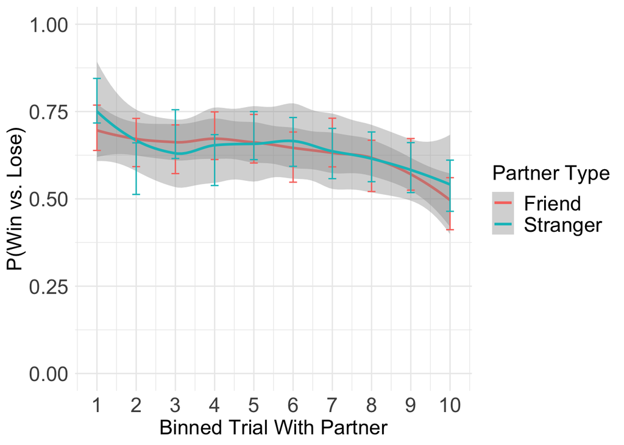

```r
df_win_lose2 = df_win_lose2 %>%
  mutate(
    outcome_numeric = case_when(
      trial_result == "Won" ~ 1,
      trial_result == "Lost" ~ 0
    )
  )


df_win_lose2 %>%
  mutate(binned_trial = ntile(trial_with_partner, n = 10)) %>%
  group_by(binned_trial, pair_type) %>%
  summarise(success = mean(outcome_numeric),
            se = sd(outcome_numeric)/sqrt(n())) %>%
  ggplot(aes(x = binned_trial,
             y = success,
             color = pair_type)) +
  geom_smooth() +
  geom_errorbar(aes(ymin = success - 2*se,
                  ymax = success + 2*se),
              width=.2) +
  labs(x = "Binned Trial With Partner",
       y = "P(Win vs. Lose)",
       color = "Partner Type") +
  scale_y_continuous(limits = c(0, 1)) +
  scale_x_continuous(breaks = c(1:10)) +
  theme_minimal() +
  theme(axis.title = element_text(size=rel(1.5)),
        axis.text = element_text(size = rel(1.5)),
        legend.text = element_text(size = rel(1.5)),
        strip.text.x = element_text(size = rel(1.5)),
        plot.title = element_text(size = rel(1.5)),
        legend.title = element_text(size = rel(1.5)))
```

```r
ggsave("../../Figures/behavioral/losing.png", dpi = 300)
```

#### Primary analyses

It appears that a fixed effect of `pair_type` does not explain significantly more variance than a model omitting this term, nor does an interaction between `pair_type * trial_with_partner`.

```r
model_interaction = glmer(data = df_win_lose2,
                          trial_result ~
                            pair_type * trial_with_partner +
                          (1 | ppt_id) +
                          (1 | partner_id) +
                          (1 | Order) +
                          (1 | session_id) +
                          (1 | color),
                        # control=glmerControl(optimizer="bobyqa"),
                        family = binomial())
```

```
## boundary (singular) fit: see ?isSingular
```

```r
model_with_pair_type = glmer(data = df_win_lose2,
                          trial_result ~
                            pair_type +
                           trial_with_partner +
                          (1 | ppt_id) +
                          (1 | partner_id) +
                          (1 + pair_type | Order) +
                          (1 | session_id) +
                          (1 | color),
                        control=glmerControl(optimizer="bobyqa"),
                        family = binomial())
```

```
## boundary (singular) fit: see ?isSingular
```

```r
model_final_base = glmer(data = df_win_lose2,
                          trial_result ~
                           trial_with_partner +
                          (1 | ppt_id) +
                          (1 | partner_id) +
                          (1 + pair_type | Order) +
                          (1 | session_id) +
                          (1 | color),
                        control=glmerControl(optimizer="bobyqa"),
                        family = binomial())
```

```
## boundary (singular) fit: see ?isSingular
```

```r
summary(model_interaction)
```

```
## Generalized linear mixed model fit by maximum likelihood (Laplace
##   Approximation) [glmerMod]
##  Family: binomial  ( logit )
## Formula: trial_result ~ pair_type * trial_with_partner + (1 | ppt_id) +
##     (1 | partner_id) + (1 | Order) + (1 | session_id) + (1 |      color)
##    Data: df_win_lose2
##
##      AIC      BIC   logLik deviance df.resid
##   4718.5   4774.4  -2350.2   4700.5     3667
##
## Scaled residuals:
##     Min      1Q  Median      3Q     Max
## -2.3108 -1.1136  0.6058  0.7719  1.1770
##
## Random effects:
##  Groups     Name        Variance Std.Dev.
##  partner_id (Intercept) 0.002161 0.04649
##  ppt_id     (Intercept) 0.001713 0.04139
##  session_id (Intercept) 0.141156 0.37571
##  color      (Intercept) 0.006068 0.07790
##  Order      (Intercept) 0.000000 0.00000
## Number of obs: 3676, groups:
## partner_id, 68; ppt_id, 65; session_id, 17; color, 4; Order, 2
##
## Fixed effects:
##                                        Estimate Std. Error z value Pr(>|z|)
## (Intercept)                           0.9347697  0.1394802   6.702 2.06e-11 ***
## pair_typeStranger                     0.0012123  0.1411056   0.009  0.99315
## trial_with_partner                   -0.0173371  0.0047594  -3.643  0.00027 ***
## pair_typeStranger:trial_with_partner  0.0001574  0.0067347   0.023  0.98135
## ---
## Signif. codes:  0 '***' 0.001 '**' 0.01 '*' 0.05 '.' 0.1 ' ' 1
##
## Correlation of Fixed Effects:
##             (Intr) pr_tyS trl_w_
## pr_typStrng -0.485
## trl_wth_prt -0.597  0.590
## pr_typSt:__  0.422 -0.867 -0.692
## convergence code: 0
## boundary (singular) fit: see ?isSingular
```

```r
anova(model_interaction, model_with_pair_type)
```

```
## Data: df_win_lose2
## Models:
## model_interaction: trial_result ~ pair_type * trial_with_partner + (1 | ppt_id) +
## model_interaction:     (1 | partner_id) + (1 | Order) + (1 | session_id) + (1 |
## model_interaction:     color)
## model_with_pair_type: trial_result ~ pair_type + trial_with_partner + (1 | ppt_id) +
## model_with_pair_type:     (1 | partner_id) + (1 + pair_type | Order) + (1 | session_id) +
## model_with_pair_type:     (1 | color)
##                      npar    AIC    BIC  logLik deviance Chisq Df Pr(>Chisq)
## model_interaction       9 4718.5 4774.4 -2350.2   4700.5
## model_with_pair_type   10 4720.5 4782.6 -2350.2   4700.5     0  1          1
```

```r
anova(model_with_pair_type, model_final_base)
```

```
## Data: df_win_lose2
## Models:
## model_final_base: trial_result ~ trial_with_partner + (1 | ppt_id) + (1 | partner_id) +
## model_final_base:     (1 + pair_type | Order) + (1 | session_id) + (1 | color)
## model_with_pair_type: trial_result ~ pair_type + trial_with_partner + (1 | ppt_id) +
## model_with_pair_type:     (1 | partner_id) + (1 + pair_type | Order) + (1 | session_id) +
## model_with_pair_type:     (1 | color)
##                      npar    AIC    BIC  logLik deviance  Chisq Df Pr(>Chisq)
## model_final_base        9 4718.5 4774.4 -2350.2   4700.5
## model_with_pair_type   10 4720.5 4782.6 -2350.2   4700.5 0.0033  1     0.9539
```